# Autonomous driving - Car detection

Welcome to your week 3 programming assignment. You will learn about object detection using the very powerful YOLO model. Many of the ideas in this notebook are described in the two YOLO papers: Redmon et al., 2016 (https://arxiv.org/abs/1506.02640) and Redmon and Farhadi, 2016 (https://arxiv.org/abs/1612.08242).

**You will learn to**:

- Use object detection on a car detection dataset
- Deal with bounding boxes

Run the following cell to load the packages and dependencies that are going to be useful for your journey!

```python
import argparse
import os
import matplotlib.pyplot as plt
from matplotlib.pyplot import imshow
import scipy.io
import scipy.misc
import numpy as np
import pandas as pd
import PIL
import tensorflow as tf
from keras import backend as K
from keras.layers import Input, Lambda, Conv2D
from keras.models import load_model, Model
from yolo_utils import read_classes, read_anchors, generate_colors, preprocess_image, draw_boxes, scale_boxes
from yad2k.models.keras_yolo import yolo_head, yolo_boxes_to_corners, preprocess_true_boxes, yolo_loss, yolo_body

%matplotlib inline
```

**Important Note**: As you can see, we **import Keras's backend as K.** This means that to use a Keras function in this notebook, you will need to write: `K.function(...)`.

## 1 - Problem Statement

You are working on a self-driving car. As a critical component of this project, you'd like to first build a car detection system. To collect data, you've mounted a camera to the hood (meaning the front) of the car, which takes pictures of the road ahead every few seconds while you drive around.

[video not shown]

Pictures taken from a car-mounted camera while driving around Silicon Valley.  
We would like to especially thank [drive.ai](https://www.drive.ai/) for providing this dataset! Drive.ai is a company building the brains of self-driving vehicles.

[figure not shown]

You've gathered all these images into a folder and have labelled them by drawing bounding boxes around every car you found. Here's an example of what your bounding boxes look like.

[figure not shown]

**Figure 1** : **Definition of a box**

If you have **80 classes** that you want YOLO to recognize, you can represent the class label $c$ either as an **integer** from 1 to 80, or as an **80-dimensional vector** (with 80 numbers) one component of which is 1 and the rest of which are 0. The video lectures had used the latter representation; in this notebook, we will use both representations, depending on which is more convenient for a particular step.

In this exercise, you will learn how YOLO works, then apply it to car detection. Because the **YOLO model is very computationally expensive to train,** we will **load pre-trained weights** for you to use.

## 2 - YOLO

YOLO ("you only look once") is a popular algoritm because it achieves high accuracy while also being able to run in real-time. This algorithm "only looks once" at the image in the sense that it **requires only one forward propagation pass** through the network to make predictions.（**仅需一次前向传播就能预测**） After **non-max suppression**, it then outputs recognized objects together with the bounding boxes.

### 2.1 - Model details

First things to know:

- The **input** is a batch of images of shape (m, 608, 608, 3)
- The **output** is a list of bounding boxes(边界框) along with the recognized classes. Each **bounding box** is represented by 6 numbers $(p_c, b_x, b_y, b_h, b_w, c)$ as explained above.（C的值为1-80） If you expand $c$ into an 80-dimensional vector, each bounding box is then represented by 85 numbers（C1...C80）.

We will use 5 **anchor boxes**(让一个格子能检测多个对象). So you can think of the YOLO architecture as the following: IMAGE (m, 608, 608, 3) -> DEEP CNN -> ENCODING (m, 19, 19, 5, 85).

Lets look in greater detail at what this encoding represents.

[figure not shown]

**Figure 2** : **Encoding architecture for YOLO**

If the center/midpoint of an object falls into a grid cell, that grid cell is responsible for detecting that object.

Since we are using 5 anchor boxes, each of the 19 x19 cells thus encodes information about 5 boxes. Anchor boxes are defined only by their width and height.

For simplicity, we will **flatten** the last two last dimensions of the shape **(19, 19, 5, 85)** encoding. So the output of the Deep CNN is **(19, 19, 425)**.(最后两个维度合在一起)（19*19个格子，每个格子都输出5个anchor boxes的结果）

[figure not shown]

**Figure 3** : **Flattening the last two last dimensions**

Now, for each box (of each cell) we will compute the following elementwise product and extract a probability that the box contains a certain class.（**每个格子中的每个anchor box都计算出80个概率值，保留最大概率值的那个类别作为该box的输出C的值**）

[figure not shown]

**Figure 4** : **Find the class detected by each box**

Here's one way to **visualize** what YOLO is predicting on an image:

- For each of the 19x19 grid cells, find the maximum of the probability scores (taking a max across both the 5 anchor boxes and across different classes).
- Color that grid cell according to what object that grid cell considers the most likely.

Doing this results in this picture:

[figure not shown]

**Figure 5** : Each of the 19x19 grid cells colored according to which class has the largest predicted probability in that cell.

Note that this visualization isn't a core part of the YOLO algorithm itself for making predictions; it's just a nice way of visualizing an intermediate result of the algorithm.

Another way to **visualize** YOLO's output is to plot the **bounding boxes** that it outputs. Doing that results in a visualization like this:

[figure not shown]

**Figure 6** : Each cell gives you 5 boxes. In total, the model predicts: **19x19x5 = 1805 boxes** just by looking once at the image (one forward pass through the network)! Different colors denote different classes.

上面有的连续几个格子都包含一个对象，所以有的格子很大

In the figure above, we plotted only boxes that the model had assigned a high probability to, but this is still **too many boxes.** You'd like to filter the algorithm's output down to a much smaller number of detected objects. To do so, you'll use **non-max suppression**. Specifically, you'll carry out these steps:

**运行非最大值抑制**

- Get rid of boxes with a **low score** (meaning, the box is not very confident about detecting a class)
- Select only one box when several boxes **overlap** with each other and detect the same object.

### 2.2 - Filtering with a threshold on class scores 滤掉概率很低的格子

You are going to apply a first filter by thresholding. You would like to **get rid of any box for which the class "score" is less than a chosen threshold**.

The model gives you a total of 19x19x5x85 numbers, with each box described by 85 numbers. It'll be convenient to rearrange the (19,19,5,85) (or (19,19,425)) dimensional tensor into the following variables: **把神经网络输出的张量分为几个部分**

- `box_confidence`: tensor of shape $(19 \times 19, 5, 1)$ containing $p_c$ (confidence probability that there's some object) for each of the 5 boxes predicted in each of the 19x19 cells.
- `boxes`: tensor of shape $(19 \times 19, 5, 4)$ containing $(b_x, b_y, b_h, b_w)$ for each of the 5 boxes per cell.
- `box_class_probs`: tensor of shape $(19 \times 19, 5, 80)$ containing the detection probabilities $(c_1, c_2, ... c_{80})$ for each of the 80 classes for each of the 5 boxes per cell.

**Exercise**: Implement `yolo_filter_boxes()`.

1. Compute box scores by doing the elementwise product(逐元素乘积) as described in **Figure 4.** The following code may help you choose the right operator:

   ```
   a = np.random.randn(19*19, 5, 1)
   b = np.random.randn(19*19, 5, 80)
   c = a * b # shape of c will be (19*19, 5, 80)
   ```

2. For each box, find:
   - the **index of the class** with the maximum box score ([Hint](https://keras.io/backend/#argmax)) (Be careful with what axis you choose; consider using axis=-1)
   - the corresponding box score ([Hint](https://keras.io/backend/#max)) (Be careful with what axis you choose; consider using axis=-1)
3. Create a **mask** by using a threshold. As a reminder: `([0.9, 0.3, 0.4, 0.5, 0.1] < 0.4)` returns: `[False, True, False, False, True]`. The mask should be True for the boxes you want to keep.
4. Use TensorFlow to apply the mask to box_class_scores, boxes and box_classes to filter out the boxes we don't want. You should be left with just the subset of boxes you want to keep. ([Hint](https://www.tensorflow.org/api_docs/python/tf/boolean_mask))

Reminder: to call a **Keras function**, you should use `K.function(...)`.

```python
# GRADED FUNCTION: yolo_filter_boxes

def yolo_filter_boxes(box_confidence, boxes, box_class_probs, threshold = .6):
    """Filters YOLO boxes by thresholding on object and class confidence.

    Arguments:
    box_confidence -- tensor of shape (19, 19, 5, 1) #有没有对象存在pc
    boxes -- tensor of shape (19, 19, 5, 4) #对象位置坐标bx,by,bh,bw
    box_class_probs -- tensor of shape (19, 19, 5, 80) #80个对象存在的概率
    threshold -- real value, if [ highest class probability score < threshold], then get rid of the corresponding box

    Returns:
    scores -- tensor of shape (None,), containing the class probability score(类别得分) for selected boxes
    boxes -- tensor of shape (None, 4), containing (b_x, b_y, b_h, b_w) coordinates of selected boxes
    classes -- tensor of shape (None,), containing the index of the class detected by the selected boxes

    Note: "None" is here because you don't know the exact number of selected boxes, as it depends on the threshold.
    For example, the actual output size of scores would be (10,) if there are 10 boxes.
    """

    # Step 1: Compute box scores
    ### START CODE HERE ### (≈ 1 line)
    box_scores = box_confidence * box_class_probs  #见图4，每个格子中每个anchor box中80个对象的得分 (19, 19, 5, 80)
    ### END CODE HERE ###

    # Step 2: Find the box_classes thanks to the max box_scores, keep track of the corresponding score
    ### START CODE HERE ### (≈ 2 lines)
    box_classes = K.argmax(box_scores, axis=-1)   #最大值下标，argmax(f(x))是使得 f(x)取得最大值所对应的变量x，即下标
    box_class_scores = K.max(box_scores, axis=-1) #最大得分值，axis=-1表示最后一个维度，此处=3
    ### END CODE HERE ###

    # Step 3: Create a filtering mask based on "box_class_scores" by using "threshold". The mask should have the
    # same dimension as box_class_scores, and be True for the boxes you want to keep (with probability >= threshold)
    ### START CODE HERE ### (≈ 1 line)
    filtering_mask = (box_class_scores >= threshold)
    ### END CODE HERE ###

    # Step 4: Apply the mask to scores, boxes and classes 过滤掉概率低的格子
    ### START CODE HERE ### (≈ 3 lines)
    scores = tf.boolean_mask(box_class_scores,filtering_mask)
    boxes = tf.boolean_mask(boxes,filtering_mask)
    classes = tf.boolean_mask(box_classes,filtering_mask)
    ### END CODE HERE ###

    return scores, boxes, classes
```

```python
with tf.Session() as test_a:
    box_confidence = tf.random_normal([19, 19, 5, 1], mean=1, stddev=4, seed = 1)
    boxes = tf.random_normal([19, 19, 5, 4], mean=1, stddev=4, seed = 1)
    box_class_probs = tf.random_normal([19, 19, 5, 80], mean=1, stddev=4, seed = 1)
    scores, boxes, classes = yolo_filter_boxes(box_confidence, boxes, box_class_probs, threshold = 0.5)
    print("scores[2] = " + str(scores[2].eval())) #scores[2]表示输出结果中第二个对象的得分
    print("boxes[2] = " + str(boxes[2].eval()))
    print("classes[2] = " + str(classes[2].eval()))
    print("scores.shape = " + str(scores.shape)) #？表示不确定目标检测结果中有几个对象
    print("boxes.shape = " + str(boxes.shape))
    print("classes.shape = " + str(classes.shape))
```

```
scores[2] = 10.7506
boxes[2] = [ 8.42653275  3.27136683 -0.53134358 -4.94137335]
classes[2] = 7
scores.shape = (?,)
boxes.shape = (?, 4)
classes.shape = (?,)
```

**Expected Output**:

| **scores[2]** | 10.7506 |
| --- | --- |
| **boxes[2]** | [ 8.42653275 3.27136683 -0.5313437 -4.94137383] |
| **classes[2]** | 7 |
| **scores.shape** | (?,) |
| **boxes.shape** | (?, 4) |
| **classes.shape** | (?,) |

### 2.3 - Non-max suppression 非最大值抑制

Even after filtering by thresholding over the classes scores, you still end up a lot of **overlapping boxes**. A second filter for selecting the right boxes is called non-maximum suppression (NMS). 防止一个物体被标记好几次

[figure not shown]

**Figure 7** : In this example, the model has predicted 3 cars, but it's actually 3 predictions of the same car. Running non-max suppression (NMS) will select only the most accurate (highest probabiliy) one of the 3 boxes.

Non-max suppression uses the very important function called **"Intersection over Union"**, or IoU.交并比

[figure not shown]

**Figure 8** : Definition of "Intersection over Union".

**Exercise**: Implement iou(). Some hints:

- In this exercise only, we define a box using its **two corners** (upper left and lower right): (x1, y1, x2, y2) rather than the midpoint and height/width.（**在本次练习中我们用左上角和右下角的坐标来表示一个box**）
- To calculate the area of a rectangle you need to multiply its height (y2 - y1) by its width (x2 - x1)
- You'll also need to find the coordinates (xi1, yi1, xi2, yi2) of the intersection of two boxes. Remember that:
  - xi1 = maximum of the x1 coordinates of the two boxes
  - yi1 = maximum of the y1 coordinates of the two boxes
  - xi2 = minimum of the x2 coordinates of the two boxes
  - yi2 = minimum of the y2 coordinates of the two boxes

In this code, we use the convention that (0,0) is the top-left corner of an image, (1,0) is the upper-right corner, and (1,1) the lower-right corner.

```python
# GRADED FUNCTION: iou
# 计算交并比
def iou(box1, box2):
    """Implement the intersection over union (IoU) between box1 and box2

    Arguments:
    box1 -- first box, list object with coordinates (x1, y1, x2, y2)
    box2 -- second box, list object with coordinates (x1, y1, x2, y2)
    """

    # Calculate the (y1, x1, y2, x2) coordinates of the intersection of box1 and box2. Calculate its Area.
    ### START CODE HERE ### (≈ 5 lines)
    xi1 = np.maximum(box1[0],box2[0])
    yi1 = np.maximum(box1[1],box2[1])
    xi2 = np.minimum(box1[2],box2[2])
    yi2 = np.minimum(box1[3],box2[3])
    inter_area = (yi2 - yi1) * (xi2 - xi1) #交集部分
    ### END CODE HERE ###

    # Calculate the Union area by using Formula: Union(A,B) = A + B - Inter(A,B)
    ### START CODE HERE ### (≈ 3 lines)
    box1_area = (box1[3] - box1[1]) * (box1[2] - box1[0])
    box2_area = (box2[3] - box2[1]) * (box2[2] - box2[0])
    union_area = box1_area + box2_area - inter_area #并集部分
    ### END CODE HERE ###

    # compute the IoU
    ### START CODE HERE ### (≈ 1 line)
    iou = inter_area / union_area
    ### END CODE HERE ###

    return iou
```

```python
box1 = (2, 1, 4, 3)
box2 = (1, 2, 3, 4)
print("iou = " + str(iou(box1, box2)))
```

```
iou = 0.142857142857
```

**Expected Output**:

| **iou = ** | 0.14285714285714285 |
| --- | --- |

You are now ready to **implement non-max suppression**. The key steps are:

1. Select the box that has the highest score. 选择得分最高的box
2. Compute its overlap with all other boxes, and remove boxes that overlap it more than `iou_threshold`.（将与最高得分box交并比大于0.5（重叠的多）的box移除）
3. Go back to step 1 and iterate until there's no more boxes with a lower score than the current selected box.

**This will remove all boxes that have a large overlap with the selected boxes. Only the "best" boxes remain.**

**Exercise**: Implement yolo_non_max_suppression() using TensorFlow. TensorFlow has two built-in functions that are used to implement **non-max suppression** (so you don't actually need to use your `iou()` implementation): **tensorflow中有内置函数实现非最大值抑制，所以不用我们自己实现的IoU函数**

- [tf.image.non_max_suppression()](https://www.tensorflow.org/api_docs/python/tf/image/non_max_suppression)
- [K.gather()](https://www.tensorflow.org/api_docs/python/tf/gather)

```python
# GRADED FUNCTION: yolo_non_max_suppression

def yolo_non_max_suppression(scores, boxes, classes, max_boxes = 10, iou_threshold = 0.5):
    """
    Applies Non-max suppression (NMS) to set of boxes

    Arguments:
    scores -- tensor of shape (None,), output of yolo_filter_boxes()，上面函数的输出作为输入，滤掉小概率后的结果
    boxes -- tensor of shape (None, 4), output of yolo_filter_boxes() that have been scaled to the image size (see later)
    classes -- tensor of shape (None,), output of yolo_filter_boxes()
    max_boxes -- integer, maximum number of predicted boxes you'd like  输出最多box数量
    iou_threshold -- real value, "intersection over union" threshold used for NMS filtering

    Returns:
    scores -- tensor of shape (, None), predicted score for each box 得分
    boxes -- tensor of shape (4, None), predicted box coordinates 坐标
    classes -- tensor of shape (, None), predicted class for each box 类别

    Note: The "None" dimension of the output tensors has obviously to be less than max_boxes. Note also that this
    function will transpose（转置） the shapes of scores, boxes, classes. This is made for convenience.
    """

    max_boxes_tensor = K.variable(max_boxes, dtype='int32')     # tensor to be used in tf.image.non_max_suppression()
    K.get_session().run(tf.variables_initializer([max_boxes_tensor])) # initialize variable max_boxes_tensor

    # Use tf.image.non_max_suppression() to get the list of indices corresponding to boxes you keep
    ### START CODE HERE ### (≈ 1 line)
    nms_indices = tf.image.non_max_suppression(boxes, scores, max_boxes, iou_threshold) #执行非最大值抑制，得到索引
    '''
    non_max_suppression(
    boxes,
    scores,
    max_output_size,
    iou_threshold=0.5,
    name=None
    )
    '''
    ### END CODE HERE ###

    # Use K.gather() to select only nms_indices from scores, boxes and classes
    ### START CODE HERE ### (≈ 3 lines)
    scores = tf.gather(scores,nms_indices)
    boxes = tf.gather(boxes,nms_indices)
    classes = tf.gather(classes,nms_indices)
    ### END CODE HERE ###

    return scores, boxes, classes
```

```python
with tf.Session() as test_b:
    scores = tf.random_normal([54,], mean=1, stddev=4, seed = 1)#54个box中，每个box对应的最大scores？
    boxes = tf.random_normal([54, 4], mean=1, stddev=4, seed = 1)
    classes = tf.random_normal([54,], mean=1, stddev=4, seed = 1)
    scores, boxes, classes = yolo_non_max_suppression(scores, boxes, classes)
    print("scores[2] = " + str(scores[2].eval()))
    print("boxes[2] = " + str(boxes[2].eval()))
    print("classes[2] = " + str(classes[2].eval()))
    print("scores.shape = " + str(scores.eval().shape)) #最后输出了10个box（max_boxes=10）
    print("boxes.shape = " + str(boxes.eval().shape))
    print("classes.shape = " + str(classes.eval().shape))
```

```
scores[2] = 6.9384
boxes[2] = [-5.299932    3.13798141  4.45036697  0.95942086]
classes[2] = -2.24527
scores.shape = (10,)
boxes.shape = (10, 4)
classes.shape = (10,)
```

**Expected Output**:

| **scores[2]** | 6.9384 |
| --- | --- |
| **boxes[2]** | [-5.299932 3.13798141 4.45036697 0.95942086] |
| **classes[2]** | -2.24527 |
| **scores.shape** | (10,) |
| **boxes.shape** | (10, 4) |
| **classes.shape** | (10,) |

### 2.4 Wrapping up the filtering

It's time to implement a function taking the output of the **deep CNN** (the 19x19x5x85 dimensional encoding) and **filtering through all the boxes** using the functions you've just implemented.

**Exercise**: Implement `yolo_eval()` which **takes the output of the YOLO encoding and filters the boxes using score threshold** and **NMS**. There's just one last implementational detail you have to know. There're a few ways of representing boxes, such as via their **corners** or via their **midpoint and height/width**（box的表示方法）. YOLO converts between a few such formats at different times, using the following functions (which we have provided):

```
boxes = yolo_boxes_to_corners(box_xy, box_wh) #将box的中点/宽高表示转化为左上角/右下角顶点表示
```

which converts the yolo box coordinates (x,y,w,h) to box corners' coordinates (x1, y1, x2, y2) to fit the input of `yolo_filter_boxes`

```
boxes = scale_boxes(boxes, image_shape)
```

YOLO's network was trained to run on 608x608 images. If you are **testing** this data on a **different size image**--for example, the car detection dataset had 720x1280 images--this step **rescales the boxes** so that they can be plotted on top of the original 720x1280 image.

Don't worry about these two functions; we'll show you where they need to be called.

```python
# GRADED FUNCTION: yolo_eval

def yolo_eval(yolo_outputs, image_shape = (720., 1280.), max_boxes=10, score_threshold=.6, iou_threshold=.5):
    """
    Converts the output of YOLO encoding (a lot of boxes) to your predicted boxes along with their scores, box coordinates and classes.

    Arguments:
    yolo_outputs -- output of the encoding model (for image_shape of (608, 608, 3)), contains 4 tensors:
                    box_confidence: tensor of shape (None, 19, 19, 5, 1) #每个anchor box有无对象
                    box_xy: tensor of shape (None, 19, 19, 5, 2) #对象box坐标
                    box_wh: tensor of shape (None, 19, 19, 5, 2)
                    box_class_probs: tensor of shape (None, 19, 19, 5, 80) #每个anchor box中对应80个对象的概率
    image_shape -- tensor of shape (2,) containing the input shape, in this notebook we use (608., 608.) (has to be float32 dtype)
    max_boxes -- integer, maximum number of predicted boxes you'd like #输出的box最大数量
    score_threshold -- real value, if [ highest class probability score < threshold], then get rid of the corresponding box #概率低的box滤掉
    iou_threshold -- real value, "intersection over union" threshold used for NMS filtering #交并比大于threshold的重叠box就抑制掉

    Returns:
    scores -- tensor of shape (None, ), predicted score for each box
    boxes -- tensor of shape (None, 4), predicted box coordinates
    classes -- tensor of shape (None,), predicted class for each box
    """

    ### START CODE HERE ###

    # Retrieve outputs of the YOLO model (≈1 line)
    box_confidence, box_xy, box_wh, box_class_probs = yolo_outputs

    # Convert boxes to be ready for filtering functions
    boxes = yolo_boxes_to_corners(box_xy, box_wh) #将box的中点/宽高表示转化为左上角/右下角顶点表示

    # Use one of the functions you've implemented to perform Score-filtering with a threshold of score_threshold (≈1 line)
    scores, boxes, classes = yolo_filter_boxes(box_confidence, boxes, box_class_probs, score_threshold) #滤掉概率低的box

    # Scale boxes back to original image shape.
    boxes = scale_boxes(boxes, image_shape)

    # Use one of the functions you've implemented to perform Non-max suppression with a threshold of iou_threshold (≈1 line)
    scores, boxes, classes = yolo_non_max_suppression(scores, boxes, classes)#非最大值抑制，滤掉重叠部分

    ### END CODE HERE ###

    return scores, boxes, classes
```

```python
with tf.Session() as test_b:
    yolo_outputs = (tf.random_normal([19, 19, 5, 1], mean=1, stddev=4, seed = 1),
                    tf.random_normal([19, 19, 5, 2], mean=1, stddev=4, seed = 1),
                    tf.random_normal([19, 19, 5, 2], mean=1, stddev=4, seed = 1),
                    tf.random_normal([19, 19, 5, 80], mean=1, stddev=4, seed = 1))
    scores, boxes, classes = yolo_eval(yolo_outputs)
    print("scores[2] = " + str(scores[2].eval()))
    print("boxes[2] = " + str(boxes[2].eval()))
    print("classes[2] = " + str(classes[2].eval()))
    print("scores.shape = " + str(scores.eval().shape))
    print("boxes.shape = " + str(boxes.eval().shape)) #输出10个框框，预测了10个对象
    print("classes.shape = " + str(classes.eval().shape))
```

```
scores[2] = 138.791
boxes[2] = [ 1292.32971191  -278.52166748  3876.98925781  -835.56494141]
classes[2] = 54
scores.shape = (10,)
boxes.shape = (10, 4)
classes.shape = (10,)
```

**Expected Output**:

| **scores[2]** | 138.791 |
| --- | --- |
| **boxes[2]** | [ 1292.32971191 -278.52166748 3876.98925781 -835.56494141] |
| **classes[2]** | 54 |
| **scores.shape** | (10,) |
| **boxes.shape** | (10, 4) |
| **classes.shape** | (10,) |

**Summary for YOLO**:

- Input image (608, 608, 3)
- The input image goes through a **CNN** , resulting in a (19,19,5,85) dimensional output. （首先要将图片输入到神经网络，得到每个网格中的每个anchor box中每个对象的概率）
- After **flattening** the last two dimensions, the output is a volume of shape (19, 19, 425):
  - Each cell in a 19x19 grid over the input image gives 425 numbers.
  - 425 = 5 x 85 because **each cell contains predictions for 5 boxes**, corresponding to 5 anchor boxes, as seen in lecture.
  - 85 = 5 + 80 where 5 is because $(p_c, b_x, b_y, b_h, b_w)$ has 5 numbers, and and 80 is the number of classes we'd like to detect
- You then select only few boxes based on:
  - **Score-thresholding**: throw away boxes that have detected a class with a score less than the threshold（滤掉得分低的box）
  - **Non-max suppression**: Compute the Intersection over Union and avoid selecting **overlapping boxes**（非最大值抑制，滤掉重叠部分）
- This gives you YOLO's final output.

## 3 - Test YOLO pretrained model on images

In this part, you are going to use a **pretrained model** and test it on the car detection dataset. As usual, you start by **creating a session to start your graph**. Run the following cell.

```python
sess = K.get_session() #creating a session to start your graph
```

### 3.1 - Defining classes, anchors and image shape.

Recall that we are trying to detect **80 classes**, and are using **5 anchor boxes**. We have gathered the information about the 80 classes and 5 boxes in two files "coco_classes.txt" and "yolo_anchors.txt". Let's load these quantities into the model by running the next cell.

The car detection dataset has 720x1280 images, which we've pre-processed into 608x608 images.

```python
class_names = read_classes("model_data/coco_classes.txt")#person、bicycle、car、motorbike、aeroplane...
anchors = read_anchors("model_data/yolo_anchors.txt") #值为0.57273, 0.677385, 1.87446, 2.06253, 3.33843, 5.47434, 7.88282, 3.52778, 9.77052, 9.16828
#image_shape = (720., 1280.)  #根据测试图片大小设置
image_shape = (375., 500.)
```

### 3.2 - Loading a pretrained model 直接导入预训练好的模型，不需要再训练CNN了

Training a YOLO model **takes a very long time** and requires a fairly large dataset of **labelled bounding boxes for a large range of target classes.** You are going to load an existing pretrained Keras YOLO model stored in "yolo.h5". (These weights come from the **official YOLO website**, and were converted using a function written by Allan Zelener. References are at the end of this notebook. Technically, these are the parameters from the **"YOLOv2" model,** but we will more simply refer to it as "YOLO" in this notebook.) Run the cell below to load the model from this file.

```python
yolo_model = load_model("model_data/yolo.h5")
```

```
/Library/Frameworks/Python.framework/Versions/3.6/lib/python3.6/site-packages/keras/models.py:252: UserWarning: No training configuration found in save file: the model was *not* compiled. Compile it manually.
  warnings.warn('No training configuration found in save file: '
```

This loads the weights of a trained YOLO model. Here's a summary of the layers your model contains.

```python
yolo_model.summary() #经过很多卷积、池化等操作，最终输出(19,19,425) 的矩阵
```

```
__________________________________________________________________________________________________
Layer (type)                    Output Shape         Param #     Connected to
==================================================================================================
input_1 (InputLayer)            (None, 608, 608, 3)  0
__________________________________________________________________________________________________
conv2d_1 (Conv2D)               (None, 608, 608, 32) 864         input_1[0][0]
__________________________________________________________________________________________________
batch_normalization_1 (BatchNor (None, 608, 608, 32) 128         conv2d_1[0][0]
__________________________________________________________________________________________________
leaky_re_lu_1 (LeakyReLU)       (None, 608, 608, 32) 0           batch_normalization_1[0][0]
__________________________________________________________________________________________________
max_pooling2d_1 (MaxPooling2D)  (None, 304, 304, 32) 0           leaky_re_lu_1[0][0]
__________________________________________________________________________________________________
conv2d_2 (Conv2D)               (None, 304, 304, 64) 18432       max_pooling2d_1[0][0]
__________________________________________________________________________________________________
batch_normalization_2 (BatchNor (None, 304, 304, 64) 256         conv2d_2[0][0]
__________________________________________________________________________________________________
leaky_re_lu_2 (LeakyReLU)       (None, 304, 304, 64) 0           batch_normalization_2[0][0]
__________________________________________________________________________________________________
max_pooling2d_2 (MaxPooling2D)  (None, 152, 152, 64) 0           leaky_re_lu_2[0][0]
__________________________________________________________________________________________________
conv2d_3 (Conv2D)               (None, 152, 152, 128 73728       max_pooling2d_2[0][0]
__________________________________________________________________________________________________
batch_normalization_3 (BatchNor (None, 152, 152, 128 512         conv2d_3[0][0]
__________________________________________________________________________________________________
leaky_re_lu_3 (LeakyReLU)       (None, 152, 152, 128 0           batch_normalization_3[0][0]
__________________________________________________________________________________________________
conv2d_4 (Conv2D)               (None, 152, 152, 64) 8192        leaky_re_lu_3[0][0]
__________________________________________________________________________________________________
batch_normalization_4 (BatchNor (None, 152, 152, 64) 256         conv2d_4[0][0]
__________________________________________________________________________________________________
leaky_re_lu_4 (LeakyReLU)       (None, 152, 152, 64) 0           batch_normalization_4[0][0]
__________________________________________________________________________________________________
conv2d_5 (Conv2D)               (None, 152, 152, 128 73728       leaky_re_lu_4[0][0]
__________________________________________________________________________________________________
batch_normalization_5 (BatchNor (None, 152, 152, 128 512         conv2d_5[0][0]
__________________________________________________________________________________________________
leaky_re_lu_5 (LeakyReLU)       (None, 152, 152, 128 0           batch_normalization_5[0][0]
__________________________________________________________________________________________________
max_pooling2d_3 (MaxPooling2D)  (None, 76, 76, 128)  0           leaky_re_lu_5[0][0]
```

[output cut: 103 more lines]

```
concatenate_1 (Concatenate)     (None, 19, 19, 1280) 0           space_to_depth_x2[0][0]
                                                                 leaky_re_lu_20[0][0]
__________________________________________________________________________________________________
conv2d_22 (Conv2D)              (None, 19, 19, 1024) 11796480    concatenate_1[0][0]
__________________________________________________________________________________________________
batch_normalization_22 (BatchNo (None, 19, 19, 1024) 4096        conv2d_22[0][0]
__________________________________________________________________________________________________
leaky_re_lu_22 (LeakyReLU)      (None, 19, 19, 1024) 0           batch_normalization_22[0][0]
__________________________________________________________________________________________________
conv2d_23 (Conv2D)              (None, 19, 19, 425)  435625      leaky_re_lu_22[0][0]
==================================================================================================
Total params: 50,983,561
Trainable params: 50,962,889
Non-trainable params: 20,672
__________________________________________________________________________________________________
```

**Note**: On some computers, you may see a warning message from Keras. Don't worry about it if you do--it is fine.

**Reminder**: this model **converts** a preprocessed **batch of input images (shape: (m, 608, 608, 3)) into a tensor of shape (m, 19, 19, 5, 85)** as explained in Figure (2).

**我们直接导入预训练好的YOLO模型，输入 (m, 608, 608, 3)的m张图片，直接得到CNN的输出 (m, 19, 19, 5, 85)，然后运行非最大值抑制得到最终目标检测的结果**

### 3.3 - Convert output of the model to usable bounding box tensors

The output of `yolo_model` is a (m, 19, 19, 5, 85) tensor that needs to pass through non-trivial processing and conversion. The following cell does that for you.

```python
yolo_outputs = yolo_head(yolo_model.output, anchors, len(class_names)) #处理一下yolo_model.output
```

You added `yolo_outputs` to your graph. This set of 4 tensors is ready to be used as input by your `yolo_eval` function.

### 3.4 - Filtering boxes

`yolo_outputs` gave you all the predicted boxes of `yolo_model` in the **correct format**. You're now ready to perform **filtering** and **select only the best boxes.** Lets now call `yolo_eval`, which you had previously implemented, to do this.

```python
scores, boxes, classes = yolo_eval(yolo_outputs, image_shape) #对CNN的输出结果进行非最大值抑制(包括滤掉得分低的box)，得到最终目标检测的结果
```

### 3.5 - Run the graph on an image

Let the fun begin. You have **created a (`sess`) graph** that can be summarized as follows:

1. yolo_model.input is given to `yolo_model`. The model is used to compute the output yolo_model.output
2. yolo_model.output is processed by `yolo_head`. It gives you yolo_outputs
3. yolo_outputs goes through a filtering function, `yolo_eval`. It **outputs your predictions:** scores, boxes, classes

**Exercise**: Implement predict() which runs the graph to test YOLO on an image. You will need to run a TensorFlow session, to have it compute `scores, boxes, classes`.

The code below also uses the following function:

```
image, image_data = preprocess_image("images/" + image_file, model_image_size = (608, 608))
```

which outputs:

- image: a python (PIL) representation of your image used for drawing boxes. You won't need to use it.
- image_data: a numpy-array representing the image. This will be the **input to the CNN.**

**Important note**: when a model uses BatchNorm (as is the case in YOLO), you will need to pass an additional placeholder in the feed_dict {K.learning_phase(): 0}.

```python
def predict(sess, image_file):
    """
    Runs the graph stored in "sess" to predict boxes for "image_file". Prints and plots the preditions.

    Arguments:
    sess -- your tensorflow/Keras session containing the YOLO graph 包含计算图的会话
    image_file -- name of an image stored in the "images" folder.

    Returns:
    out_scores -- tensor of shape (None, ), scores of the predicted boxes #None表示不知道输出的box数量，值在0-max_boxes之间
    out_boxes -- tensor of shape (None, 4), coordinates of the predicted boxes
    out_classes -- tensor of shape (None, ), class index of the predicted boxes

    Note: "None" actually represents the number of predicted boxes, it varies between 0 and max_boxes.
    """

    # Preprocess your image
    image, image_data = preprocess_image("images/JPEGImages/" + image_file, model_image_size = (608, 608))

    # Run the session with the correct tensors and choose the correct placeholders in the feed_dict.
    # You'll need to use feed_dict={yolo_model.input: ... , K.learning_phase(): 0})
    ### START CODE HERE ### (≈ 1 line) 进行目标检测
    out_scores, out_boxes, out_classes = sess.run([scores,boxes,classes],feed_dict={yolo_model.input:image_data,K.learning_phase():0})
    ### END CODE HERE ###

    # Print predictions info
    print('Found {} boxes for {}'.format(len(out_boxes), image_file)) #打印 Found 7 boxes for test.jpg
    # Generate colors for drawing bounding boxes.
    colors = generate_colors(class_names)
    # Draw bounding boxes on the image file
    draw_boxes(image, out_scores, out_boxes, out_classes, class_names, colors) #yolo_utils.py中，同时会打印出（对象类别、得分、对象位置坐标:左上/右下）
    # Save the predicted bounding box on the image
    image.save(os.path.join("out", image_file), quality=90)
    # Display the results in the notebook
    output_image = scipy.misc.imread(os.path.join("out", image_file))
    imshow(output_image)

    return out_scores, out_boxes, out_classes
```

```
Found 3 boxes for 000030.jpg
person 0.80 (52, 153) (152, 289)
bicycle 0.85 (39, 209) (180, 292)
person 0.91 (293, 136) (453, 290)
```

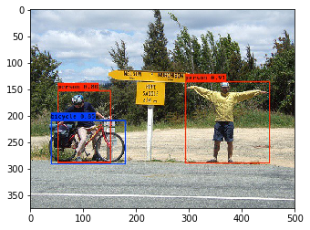

```python
out_scores, out_boxes, out_classes = predict(sess, "000030.jpg") #测试换图片时，要在前面设置大小
```

**Expected Output**:

| **Found 7 boxes for test.jpg** |  |
| --- | --- |
| **car** | 0.60 (925, 285) (1045, 374) |
| **car** | 0.66 (706, 279) (786, 350) |
| **bus** | 0.67 (5, 266) (220, 407) |
| **car** | 0.70 (947, 324) (1280, 705) |
| **car** | 0.74 (159, 303) (346, 440) |
| **car** | 0.80 (761, 282) (942, 412) |
| **car** | 0.89 (367, 300) (745, 648) |

The model you've just run is actually able to detect 80 different classes listed in "coco_classes.txt". To test the model on your own images:

```
1. Click on "File" in the upper bar of this notebook, then click "Open" to go on your Coursera Hub.
2. Add your image to this Jupyter Notebook's directory, in the "images" folder
3. Write your image's name in the cell above code
4. Run the code and see the output of the algorithm!
```

If you were to run your session in a for loop over all your images. Here's what you would get:

[video not shown]

Predictions of the YOLO model on pictures taken from a camera while driving around the Silicon Valley  
Thanks [drive.ai](https://www.drive.ai/) for providing this dataset!

**What you should remember**:

- YOLO is a state-of-the-art(最先进的) object detection model that is fast and accurate
- It runs an input image through a **CNN** which outputs a 19x19x5x85 dimensional volume.
- The encoding can be seen as a grid where each of the **19x19 cells** contains information about **5 boxes**.
- You **filter** through all the boxes using **non-max suppression**. Specifically:
  - Score thresholding on the probability of detecting a class to keep only accurate (**high probability**) boxes
  - Intersection over Union (IoU) thresholding to eliminate **overlapping** boxes
- Because training a YOLO model from randomly initialized weights is non-trivial and requires a large dataset as well as lot of computation, we used **previously trained model parameters（模型参数已经预训练好了，我们不用训练了，直接用来直接测试）** in this exercise. If you wish, you can also try fine-tuning the YOLO model with your own dataset, though this would be a fairly non-trivial exercise.

**References**: The ideas presented in this notebook came primarily from the two YOLO papers. The implementation here also took significant inspiration and used many components from Allan Zelener's github repository. The pretrained weights used in this exercise came from the official YOLO website.

- Joseph Redmon, Santosh Divvala, Ross Girshick, Ali Farhadi - [You Only Look Once: Unified, Real-Time Object Detection](https://arxiv.org/abs/1506.02640) (2015)
- Joseph Redmon, Ali Farhadi - [YOLO9000: Better, Faster, Stronger](https://arxiv.org/abs/1612.08242) (2016)
- Allan Zelener - [YAD2K: Yet Another Darknet 2 Keras](https://github.com/allanzelener/YAD2K)
- The official YOLO website (https://pjreddie.com/darknet/yolo/)

**Car detection dataset**:  
<span xmlns:dct="http://purl.org/dc/terms/" property="dct:title">The Drive.ai Sample Dataset</span> (provided by drive.ai) is licensed under a [Creative Commons Attribution 4.0 International License](http://creativecommons.org/licenses/by/4.0/). We are especially grateful to Brody Huval, Chih Hu and Rahul Patel for collecting and providing this dataset.